# Datos misteriosos

### Equipo 3 (Archivo 01)

#### Alumnos: Vania Samantha Alanís Sánchez- Luis Fernando López Díaz - Nadia Berenice Pizano López

## Campamento base

#### 1. ¿Qué información hay en el archivo a simple a vista?

Hay información sobre la latitud (15°45.20') y longitud (-96°7.80' W). También se indica la institución: Servicio Mareográfico Nacionaal del Instituto de Geofísica UNAM. Se indica que 'Medido' es el valor de la altura del nivel del mar y 'Pronosticado' es el valor de la altura del nivel del mar esperado, ambos valores están indicados en m. El formato de hora señalado es GMT (Greenwich Mean Time).

#### 2. ¿Qué unidades de medición se reportan?

La altura del nivel del mar está en metros.

#### 3. ¿Estas unidades corresponden al Sistema Internacional de Unidades (SI)? SI no es así, ¿cuáles son las unidades equivalentes en el SI?

Sí está dentro de Sitema Internacional de Unidades. Se trata de una unidad fundamental del SI y su símbolo es 'm'.

#### ¿Pueden identificar cuál es valor nulo de su archivo?

El valor nulo se presenta como 0, ya que en el archivo no hay valores menores a 0.358. Además, cuando aparece un cero, no tiene concordancia con los valores anteriores y posteriores.

Para identificar los valores nulos también se puede observar la gráfica sin especificar na_values

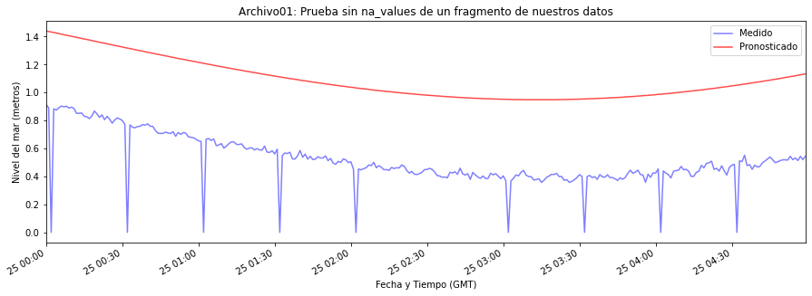

```python
import pandas as pd
import matplotlib.pyplot as plt
data_prueba = pd.read_csv('datos/archivo01.csv', header=6)
fig = plt.figure(figsize=(15.0, 5.0))
ax = fig.add_subplot(1,1,1)

fechas_datetime = pd.to_datetime(data_prueba.head(300)['Fecha'])
ax.plot(fechas_datetime,data_prueba.head(300)['Medido'], color='b', alpha=0.5, label='Medido')
ax.plot(fechas_datetime,data_prueba.head(300)['Pronosticado'], color='r', alpha=0.7, label='Pronosticado')

ax.set_ylabel('Nivel del mar (metros)')
ax.set_xlabel('Fecha y Tiempo (GMT)')
ax.set_title('Archivo01: Prueba sin na_values de un fragmento de nuestros datos')
ax.set_xlim(fechas_datetime[0], fechas_datetime[299])
ax.legend()
fig.autofmt_xdate()
```

Como se observa en la gráfica de arriba, se puede apreciar un comportamiento global, y justo cuando aparecen valores de 0, vemos descensos muy bruscos que no cuadran con el comportamiento de la gráfica, por lo que es una prueba adicional para verificar que pasa con el valor nulo que elegimos.

## Sumidero de la incertidumbre

En esta segunda etapa haremos las gráficas de sus datos.

Grafiquen los datos.

1. La primera columna les da el tiempo en que se realizó la medición. Ésta es la variable independiente. Grafiquen las variables dependientes como función del tiempo. Recuerden etiquetar correctamente los ejes y poner unidades.
2. Elijan los parámetros adecuados para una visualización óptima de los datos

```python
data = pd.read_csv('datos/archivo01.csv', header=6 , na_values=0)
```

```python
data
```

|  | Fecha | Medido | Pronosticado |
| --- | --- | --- | --- |
| 0 | '2020-09-25 00:00:00' | 0.915 | 1.441 |
| 1 | '2020-09-25 00:01:00' | 0.891 | 1.437 |
| 2 | '2020-09-25 00:02:00' | NaN | 1.433 |
| 3 | '2020-09-25 00:03:00' | 0.884 | 1.430 |
| 4 | '2020-09-25 00:04:00' | 0.875 | 1.426 |
| ... | ... | ... | ... |
| 2875 | '2020-09-26 23:55:00' | 1.260 | 1.737 |
| 2876 | '2020-09-26 23:56:00' | 1.254 | 1.736 |
| 2877 | '2020-09-26 23:57:00' | 1.255 | 1.734 |
| 2878 | '2020-09-26 23:58:00' | 1.221 | 1.733 |
| 2879 | '2020-09-26 23:59:00' | 1.203 | 1.731 |

2880 rows × 3 columns

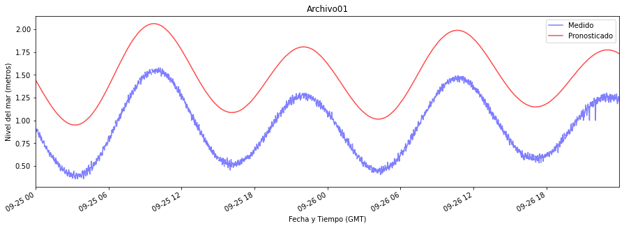

```python
fig = plt.figure(figsize=(15.0, 5.0))
ax = fig.add_subplot(1,1,1)

fechas_datetime = pd.to_datetime(data['Fecha'])
ax.plot(fechas_datetime,data['Medido'], color='b', alpha=0.5, label='Medido')
ax.plot(fechas_datetime,data['Pronosticado'], color='r', alpha=0.7, label='Pronosticado')

ax.set_ylabel('Nivel del mar (metros)')
ax.set_xlabel('Fecha y Tiempo (GMT)')
ax.set_title('Archivo01')
ax.set_xlim(fechas_datetime[0], fechas_datetime[2879])
ax.legend()
fig.autofmt_xdate()
```

## Ascenso a la cima

Esta es la parte en donde reflexionamos qué nos dicen los datos acerca del sistema.

#### Analicen los datos.

1. Observen la gráfica que obtuvieron anteriormente y analicen lo siguiente.

#### ¿La variable dependiente es directamente proporcional al tiempo transcurrido, inversamente proporcional, o ninguna?

La variable dependiente, al ser periódica, no presenta una relación de proporcionalidad. Es similar a una sinusoide por lo que se puede decir que las ordenadas son proporcionales a los senos de las abscisas.

#### ¿Observan algún ciclo?

Sí, en la gráfica se muestra una clara periocidad, ya que se ve como una onda. Se podrían señalar dos ciclos: uno al que podríamos llamar longitud de onda que, si bien no es exactamente igual cada período, sí es muy parecido cada ves. Este ciclo es aproximadamente de 12 horas. El segundo ciclo corresponde a los cambios en la altura de las crestas. Un primer ciclo correspondería a una de la crestas más altas con una de las crestas más baja (las primeras dos crestas). Éste ciclo tiene una duración aproximada de 24 horas.

#### 2. A partir de los metadatos, ¿pueden saber el lugar en donde se realizaron las mediciones? ¿Cuánto tiempo abarcan?

Sí. Parte de los metadatos son las coordenadas geográficas, por lo que fácilmente se puede saber en dónde fueron tomados. Con ayuda de google earth se logra identificar el lugar: Santa Cruz Huatulco, Crucecita, Oaxaca, México. Adicionalmente, ubicamos la estación en la página del Servicio Mareográfico. El tiempo que abarcan las mediciones es de 48 horas.

#### 3. Analizando la dependencia entre las variables, las unidades de las mediciones, y el lugar de las mediciones ¿pueden pensar en algún fenómeno físico que se explique a partir de estos datos?

Debido al comportamiento de la gráfica y a los metadatos, se podría inferir que corresponde al fenómeno físico de las mareas (ascenso y descenso periódico del nivel del mar) causado por la acción gravitatoria que ejercen el Sol y la Luna en conjunto. En este fenómeno podemos distinguir la marea alta o pleamar y la marea baja o bajamar. En la mayor parte del mundo hay dos pleamares y dos bajamares en un día lunar (24 horas con 50 minutos). Debido a que un día lunar es un poco más de 24 horas, en la gráfica no se ve que sean exactamente en 24 horas.

#### 4. Grafiquen porciones más pequeñas de sus datos. Por ejemplo solo un día, o unas horas. ¿Ven un comportamiento distinto?

Las graficas de ambas columnas muestran valores con gran similitud y un comportamiento parecido, lo cual habla de la precision del pronóstico, sin embargo sabemos por las tablas la diferencia de ambos valores, mientras mas mediciones se obtienen mas toma forma la grafica para 'Medido' pues no es una linea continua y muestra perturbaciones, ademas las graficas con valores en menor tiempo no muestran un comportamiento periodico, y se observan mas como lineas paralelas, por lo que sugiere que se requiere una gran cantidad de datos para poder hablar del fenómeno de manera mas completa. Aunque podríamos atribuir esas pequeñas perturbaciones al oleaje.

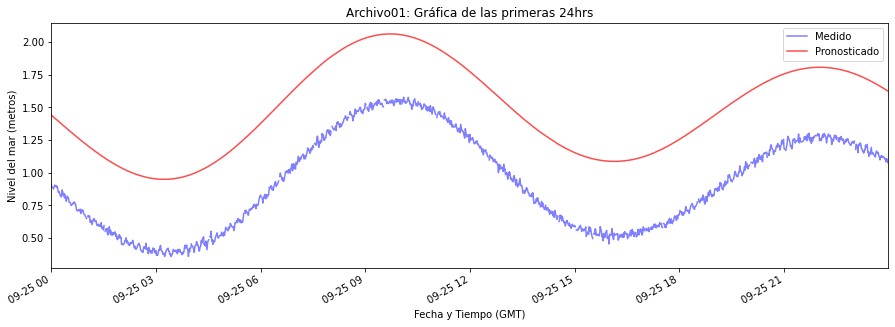

```python
fig = plt.figure(figsize=(15.0, 5.0))
ax = fig.add_subplot(1,1,1)

fechas_datetime = pd.to_datetime(data.head(1440)['Fecha'])
ax.plot(fechas_datetime,data.head(1440)['Medido'], color='b', alpha=0.5, label='Medido')
ax.plot(fechas_datetime,data.head(1440)['Pronosticado'], color='r', alpha=0.7, label='Pronosticado')

ax.set_ylabel('Nivel del mar (metros)')
ax.set_xlabel('Fecha y Tiempo (GMT)')
ax.set_title('Archivo01: Gráfica de las primeras 24hrs')
ax.set_xlim(fechas_datetime[0], fechas_datetime[1439])
ax.legend()
fig.autofmt_xdate()
```

En la gráfica de las primeras 24 horas se observa el mismo comportamiento que en la anterior. Esto era de esperarse ya que el archivo solo tiene mediciones por 48 horas y se podía apreciar cómo era la gráfica durante las primeras 24 horas.

#### Al ser un tiempo total de 48 horas, graficaremos en un octavo del tiempo total (6 horas)

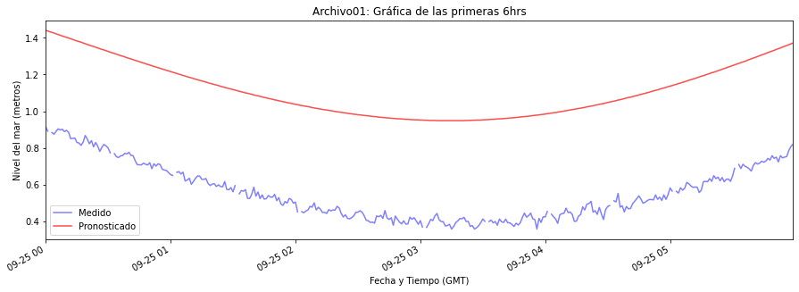

```python
fig = plt.figure(figsize=(15.0, 5.0))
ax = fig.add_subplot(1,1,1)

fechas_datetime = pd.to_datetime(data.head(360)['Fecha'])
ax.plot(fechas_datetime,data.head(360)['Medido'], color='b', alpha=0.5, label='Medido')
ax.plot(fechas_datetime,data.head(360)['Pronosticado'], color='r', alpha=0.7, label='Pronosticado')

ax.set_ylabel('Nivel del mar (metros)')
ax.set_xlabel('Fecha y Tiempo (GMT)')
ax.set_title('Archivo01: Gráfica de las primeras 6hrs')
ax.set_xlim(fechas_datetime[0], fechas_datetime[359])
ax.legend()
fig.autofmt_xdate()
```

A esta última gráfica corresponde el primer valle, por lo que debe corresponder a la bajamar. Ya no se aprecia el ciclo presentado, debido a que el tiempo que abarca la gráfica no es suficiente. Sin embargo, se pueden apreciar mejor las pequeñas variaciones que tiene el nivel del mar.

#### 5. Si hay más de una variable dependiente, comparen las dos variables dependientes (columnas 2 y 3 de sus datos). ¿Qué relación hay entre ellas? ¿Pueden explicar sus diferencias y similitudes con base en la información que tienen de cada columna? Si solo hay una variable dependiente (columna 2), ¿qué nos dice su comportamiento acerca del fenómeno físico medido? ¿Qué pasa si comparas distintos periodos de tiempo dentro de la serie de datos?

Hay dos variables dependientes: la medición y el pronóstico. Su comportamiento es muy similiar, la diferencia es que el pronóstico está desplazado aproximadamente 0.5 hacia arriba sobre el eje de las ordenadas, es decir, se pronóstico adecuadamente el comportamiento del nivel del mar, pero todos los pronósticos sobrepasan en 0.5m (aproximadamente) lo medido. El pronóstico se ve como una línea muy uniforme y la medición tiene pequeñas perturbaciones (que no afectan al comportamiento global), ya que en la naturaleza se presentan pequeñas perturbaciones.

#### 6. Bono ¿Con qué instrumentos fueron realizadas estas mediciones? ¿Cómo funciona este aparato?

Con un Mareógrafo o mareómetro. De acuerdo con el trabajo "La medición del nivel medio del mar: principios y métodos" de Josep Pons Valls, los mareógrafos miden el nivel del mar instantáneo en un lugar concreto de la costa. Miden la distancia vertical entre un punto de referencia y la superficie del mar en un determinado momento. Existen diversos tipos, pero sus fundamentos son los mismos. Usualmente se utiliza un tubo vertical fijo sumergido en el agua, con el propósito de que las olas no lo rebasen ni le hagan vacio, ademas se tapa el extremo sumergido del tubo para evitar el flujo del agua y se le perforan orificios laterales con un diámetro que permita el flujo de entrada y salida del agua que pasa por el tubo, de esta manera se filtran las oscilaciones del oleaje exterior, cuidando que la cantidad de agua sea suficiente para reflejar el nivel promedio del agua exterior, posteriormente se utilizan dispositivos que miden la distancia vertical que recorre el nivel del agua en el interior del tubo, ademas se conecta a un reloj para poder registar el momento de cada medicion con la mayor precisión posible.

#### Referencias

Pons, J. (2009). La medición del nivel del mar: principios y métodos. Recuperado de: https://upcommons.upc.edu/

También consultamos el Servicio Mareográfico de la UNAM: http://www.mareografico.unam.mx/portal/